# Air Quality Control In New York City

### Data Science Project by Fausto Llapa

#### Github: https://github.com/faustollapa

#### LinkedIn: https://www.linkedin.com/in/fausto-llapa-9901b819b/

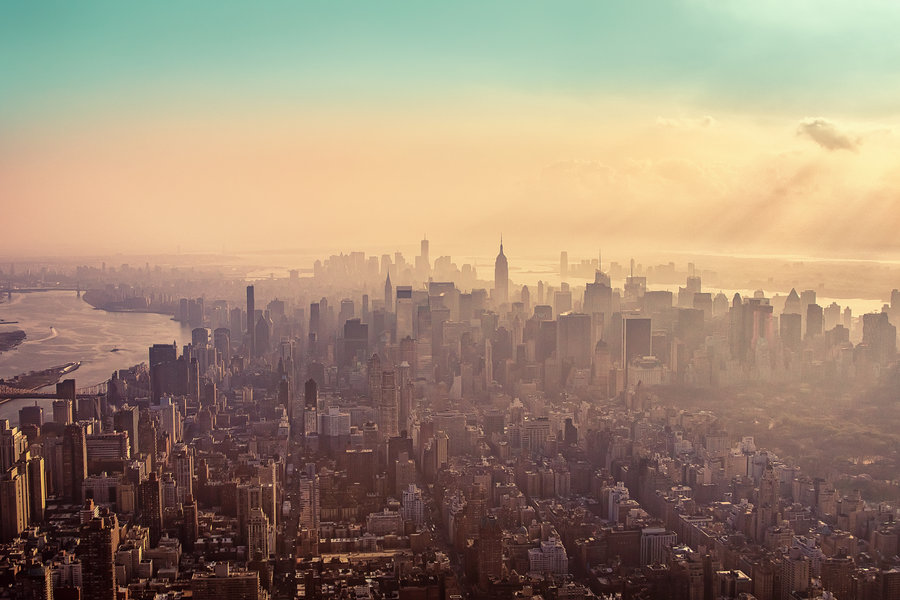

```python
Image('NYC.jpg', width = 1000)
```

## Overview

This project examines the different type of pollutants throughout the neighborhoods of New York City throughout the years. It also consists of the correlation between health cases related to the air pollutants. I used seaborn and matplotlib to visualize how much each concentration affects each neighborhood. As well as foilum to create maps to visualize the health cases and pollution across New York. It can be assumed that the more polluted areas in New York City do not have high health cases correlated to pollution.

## Techniques

To accomplish this, I combined string values from three columns into one and into a new column. I also dropped unnessacary values, eventually merging with the neighborhood dataset based on the neighborhood names. I also used functions to create multiple bar graphs, line graphs, and scatterplots. Eventually, ending it off with two foilum maps that generally views the impact of pollution and health cases in New York City.

## Data

- Air quality of NYC dataset: https://data.cityofnewyork.us/Environment/Air-Quality/c3uy-2p5r/data

This dataset consists of air pollutants and health cases related to the pollutants. Also, contain the locations, measurements, and time intervals of each pollutant/health cases. I eventually use this dataset to merge with the NYC UNF 42 dataset.

- New York City UNF 42 geojson file and dataset: https://saarabi.carto.com/tables/uhf_42_dohmh_2009/public/map

This dataset contains all 42 neighborhoods of New York City. It also contains boroughs and locations. I also used the geojson file from this website for the foilum maps.

## Resources

- https://nicksawhney.github.io/NYCAirMaps/
- https://towardsdatascience.com/using-folium-to-generate-choropleth-map-with-customised-tooltips-12e4cec42af2

# **Data Collection / Pre-Processing**

```python
import warnings
from IPython.display import Image
import pandas as pd
import seaborn as sns
import geopandas as gpd
import folium
import matplotlib.pyplot as plt
%matplotlib inline
from google.colab import files

warnings.filterwarnings('ignore')
uploaded = files.upload()
airquality = pd.read_csv("Air_Quality.csv")
airquality
```

Upload widget is only available when the cell has been executed in the current browser session. Please rerun this cell to enable.

```
Saving Air_Quality.csv to Air_Quality.csv
```

|  | Unique ID | Indicator ID | Name | Measure | Measure Info | Geo Type Name | Geo Join ID | Geo Place Name | Time Period | Start_Date | Data Value | Message |
| --- | --- | --- | --- | --- | --- | --- | --- | --- | --- | --- | --- | --- |
| 0 | 333939 | 365 | Fine Particulate Matter (PM2.5) | Mean | mcg per cubic meter | Borough | 1 | Bronx | Winter 2014-15 | 12/1/2014 | 10.21 | NaN |
| 1 | 547354 | 365 | Fine Particulate Matter (PM2.5) | Mean | mcg per cubic meter | Borough | 1 | Bronx | Annual Average 2017 | 1/1/2017 | 7.72 | NaN |
| 2 | 605650 | 365 | Fine Particulate Matter (PM2.5) | Mean | mcg per cubic meter | Borough | 1 | Bronx | Winter 2017-18 | 12/1/2017 | 8.28 | NaN |
| 3 | 179503 | 365 | Fine Particulate Matter (PM2.5) | Mean | mcg per cubic meter | Borough | 1 | Bronx | Winter 2010-11 | 12/1/2010 | 13.85 | NaN |
| 4 | 179643 | 365 | Fine Particulate Matter (PM2.5) | Mean | mcg per cubic meter | Borough | 1 | Bronx | Annual Average 2009 | 12/1/2008 | 11.05 | NaN |
| ... | ... | ... | ... | ... | ... | ... | ... | ... | ... | ... | ... | ... |
| 14284 | 131167 | 655 | O3-Attributable Asthma Hospitalizations | Estimated Annual Rate- Children 0 to 17 Yrs Old | per 100,000 children | Borough | 2 | Brooklyn | 2005-2007 | 1/1/2005 | 21.10 | NaN |
| 14285 | 518596 | 655 | O3-Attributable Asthma Hospitalizations | Estimated Annual Rate- Children 0 to 17 Yrs Old | per 100,000 children | Borough | 2 | Brooklyn | 2012-2014 | 1/2/2012 | 21.30 | NaN |
| 14286 | 151571 | 655 | O3-Attributable Asthma Hospitalizations | Estimated Annual Rate- Children 0 to 17 Yrs Old | per 100,000 children | Borough | 2 | Brooklyn | 2009-2011 | 1/1/2009 | 20.90 | NaN |
| 14287 | 628961 | 655 | O3-Attributable Asthma Hospitalizations | Estimated Annual Rate- Children 0 to 17 Yrs Old | per 100,000 children | Borough | 2 | Brooklyn | 2015-2017 | 1/1/2015 | 16.50 | NaN |
| 14288 | 131168 | 655 | O3-Attributable Asthma Hospitalizations | Estimated Annual Rate- Children 0 to 17 Yrs Old | per 100,000 children | Borough | 3 | Manhattan | 2005-2007 | 1/1/2005 | 20.10 | NaN |

14289 rows × 12 columns

```python
#This removes rows containing 'Traffic Density', year intervals '2005-2007', and keeps rows contain geo type of UHF42.
airquality = airquality[~airquality['Name'].str.startswith('Traffic Density')]
airquality = airquality[~airquality['Time Period'].str.contains('2005-2007')]
airquality = airquality[airquality['Geo Type Name'] == 'UHF42'].reset_index()
airquality
```

|  | index | Unique ID | Indicator ID | Name | Measure | Measure Info | Geo Type Name | Geo Join ID | Geo Place Name | Time Period | Start_Date | Data Value | Message |
| --- | --- | --- | --- | --- | --- | --- | --- | --- | --- | --- | --- | --- | --- |
| 0 | 223 | 410860 | 365 | Fine Particulate Matter (PM2.5) | Mean | mcg per cubic meter | UHF42 | 504 | South Beach - Tottenville | Annual Average 2016 | 12/31/2015 | 6.59 | NaN |
| 1 | 224 | 547492 | 365 | Fine Particulate Matter (PM2.5) | Mean | mcg per cubic meter | UHF42 | 504 | South Beach - Tottenville | Annual Average 2017 | 1/1/2017 | 6.58 | NaN |
| 2 | 229 | 212709 | 365 | Fine Particulate Matter (PM2.5) | Mean | mcg per cubic meter | UHF42 | 504 | South Beach - Tottenville | Winter 2013-14 | 12/1/2013 | 11.55 | NaN |
| 3 | 230 | 334077 | 365 | Fine Particulate Matter (PM2.5) | Mean | mcg per cubic meter | UHF42 | 504 | South Beach - Tottenville | Winter 2014-15 | 12/1/2014 | 8.05 | NaN |
| 4 | 231 | 410859 | 365 | Fine Particulate Matter (PM2.5) | Mean | mcg per cubic meter | UHF42 | 504 | South Beach - Tottenville | Summer 2016 | 5/31/2016 | 7.54 | NaN |
| ... | ... | ... | ... | ... | ... | ... | ... | ... | ... | ... | ... | ... | ... |
| 4993 | 14265 | 151527 | 655 | O3-Attributable Asthma Hospitalizations | Estimated Annual Rate- Children 0 to 17 Yrs Old | per 100,000 children | UHF42 | 101 | Kingsbridge - Riverdale | 2009-2011 | 1/1/2009 | 22.30 | NaN |
| 4994 | 14266 | 628965 | 655 | O3-Attributable Asthma Hospitalizations | Estimated Annual Rate- Children 0 to 17 Yrs Old | per 100,000 children | UHF42 | 101 | Kingsbridge - Riverdale | 2015-2017 | 1/1/2015 | 15.10 | NaN |
| 4995 | 14269 | 151528 | 655 | O3-Attributable Asthma Hospitalizations | Estimated Annual Rate- Children 0 to 17 Yrs Old | per 100,000 children | UHF42 | 102 | Northeast Bronx | 2009-2011 | 1/1/2009 | 32.20 | NaN |
| 4996 | 14270 | 628966 | 655 | O3-Attributable Asthma Hospitalizations | Estimated Annual Rate- Children 0 to 17 Yrs Old | per 100,000 children | UHF42 | 102 | Northeast Bronx | 2015-2017 | 1/1/2015 | 33.30 | NaN |
| 4997 | 14276 | 518600 | 655 | O3-Attributable Asthma Hospitalizations | Estimated Annual Rate- Children 0 to 17 Yrs Old | per 100,000 children | UHF42 | 101 | Kingsbridge - Riverdale | 2012-2014 | 1/2/2012 | 22.70 | NaN |

4998 rows × 13 columns

As seen in the dataset, there are columns that contain the name, time period, and measure of the pollutant/health cases. In order to get the specific values, the best way would be to combine the strings of each column so later on we can make columns containing those specific measurements within the specific time period, measurement, and pollutant/health cases.

```python
#This adds the strings from three columns together removing any unnessecary punctuation
airquality['Air Pollutant'] = (airquality['Name']
                         + ' ' + airquality['Time Period']
                         + ' ' + airquality['Measure']).str\
                        .replace(',', '')\
                        .replace('-', '')\
                        .replace(' ', '_')\
```

```python
airquality.head()
```

|  | index | Unique ID | Indicator ID | Name | Measure | Measure Info | Geo Type Name | Geo Join ID | Geo Place Name | Time Period | Start_Date | Data Value | Message | Air Pollutant |
| --- | --- | --- | --- | --- | --- | --- | --- | --- | --- | --- | --- | --- | --- | --- |
| 0 | 223 | 410860 | 365 | Fine Particulate Matter (PM2.5) | Mean | mcg per cubic meter | UHF42 | 504 | South Beach - Tottenville | Annual Average 2016 | 12/31/2015 | 6.59 | NaN | Fine Particulate Matter (PM2.5) Annual Average... |
| 1 | 224 | 547492 | 365 | Fine Particulate Matter (PM2.5) | Mean | mcg per cubic meter | UHF42 | 504 | South Beach - Tottenville | Annual Average 2017 | 1/1/2017 | 6.58 | NaN | Fine Particulate Matter (PM2.5) Annual Average... |
| 2 | 229 | 212709 | 365 | Fine Particulate Matter (PM2.5) | Mean | mcg per cubic meter | UHF42 | 504 | South Beach - Tottenville | Winter 2013-14 | 12/1/2013 | 11.55 | NaN | Fine Particulate Matter (PM2.5) Winter 2013-14... |
| 3 | 230 | 334077 | 365 | Fine Particulate Matter (PM2.5) | Mean | mcg per cubic meter | UHF42 | 504 | South Beach - Tottenville | Winter 2014-15 | 12/1/2014 | 8.05 | NaN | Fine Particulate Matter (PM2.5) Winter 2014-15... |
| 4 | 231 | 410859 | 365 | Fine Particulate Matter (PM2.5) | Mean | mcg per cubic meter | UHF42 | 504 | South Beach - Tottenville | Summer 2016 | 5/31/2016 | 7.54 | NaN | Fine Particulate Matter (PM2.5) Summer 2016 Mean |

From the air quality dataset, we see that the *Message* feature isn't going to be needed especially when all it consists of is NaN values.

```python
#Drops the message column
airquality.drop('Message', axis=1, inplace=True)
```

The New York City UNF 42 dataset is imported containing the 42 neighborhoods of New York.

```python
uploaded = files.upload()
UNF = pd.read_csv('uhf_42_dohmh_2009.csv').dropna()
UNF
```

Upload widget is only available when the cell has been executed in the current browser session. Please rerun this cell to enable.

```
Saving uhf_42_dohmh_2009.csv to uhf_42_dohmh_2009.csv
```

|  | the_geom | cartodb_id | objectid | borough | uhf_neigh | shape_area | shape_leng | uhfcode | no_insurance_coverage |
| --- | --- | --- | --- | --- | --- | --- | --- | --- | --- |
| 1 | 0106000020E61000000500000001030000000100000005... | 5 | 5 | Bronx | Pelham - Throgs Neck | 3.865737e+08 | 250903.372273 | 104 | 16.1 |
| 2 | 0106000020E61000000100000001030000000100000069... | 18 | 18 | Brooklyn | Coney Island - Sheepshead Bay | 2.288309e+08 | 101869.349860 | 210 | 14.1 |
| 3 | 0106000020E61000000200000001030000000100000005... | 32 | 32 | Queens | Flushing - Clearview | 3.622995e+08 | 125334.924243 | 403 | 18.0 |
| 4 | 0106000020E61000000200000001030000000100000004... | 37 | 37 | Queens | Jamaica | 3.645499e+08 | 123620.448330 | 408 | 17.9 |
| 5 | 0106000020E6100000010000000103000000010000005E... | 38 | 38 | Queens | Southeast Queens | 3.616017e+08 | 129288.280297 | 409 | 7.8 |
| 6 | 0106000020E610000002000000010300000001000000AD... | 39 | 39 | Queens | Rockaway | 2.657288e+08 | 232823.135817 | 410 | 15.0 |
| 7 | 0106000020E6100000020000000103000000010000000C... | 43 | 43 | Staten Island | South Beach - Tottenville | 7.311307e+08 | 175067.708940 | 504 | 11.7 |
| 8 | 0106000020E6100000010000000103000000010000002A... | 2 | 2 | Bronx | Kingsbridge - Riverdale | 1.332914e+08 | 57699.154353 | 101 | 8.4 |
| 9 | 0106000020E610000001000000010300000001000000D5... | 3 | 3 | Bronx | Northeast Bronx | 1.813708e+08 | 88219.319110 | 102 | 7.0 |
| 10 | 0106000020E610000001000000010300000001000000A5... | 4 | 4 | Bronx | Fordham - Bronx Park | 1.407724e+08 | 59711.871991 | 103 | 16.7 |
| 11 | 0106000020E610000001000000010300000001000000B7... | 6 | 6 | Bronx | Crotona - Tremont | 1.068978e+08 | 66676.089072 | 105 | 16.0 |
| 12 | 0106000020E61000000100000001030000000100000002... | 7 | 7 | Bronx | High Bridge - Morrisania | 8.589956e+07 | 50241.649324 | 106 | 16.0 |
| 13 | 0106000020E610000001000000010300000001000000EE... | 8 | 8 | Bronx | Hunts Point - Mott Haven | 1.128093e+08 | 62182.674773 | 107 | 16.0 |
| 14 | 0106000020E6100000010000000103000000010000008B... | 9 | 9 | Brooklyn | Greenpoint | 1.047836e+08 | 48036.348146 | 201 | 10.2 |
| 15 | 0106000020E6100000010000000103000000010000006E... | 10 | 10 | Brooklyn | Downtown - Heights - Slope | 1.758001e+08 | 111232.015567 | 202 | 8.0 |
| 16 | 0106000020E610000001000000010300000001000000E6... | 11 | 11 | Brooklyn | Bedford Stuyvesant - Crown Heights | 1.662263e+08 | 69711.014325 | 203 | 13.1 |
| 17 | 0106000020E610000001000000010300000001000000F2... | 12 | 12 | Brooklyn | East New York | 1.551405e+08 | 75378.418333 | 204 | 14.2 |
| 18 | 0106000020E61000000200000001030000000100000011... | 13 | 13 | Brooklyn | Sunset Park | 1.118635e+08 | 100114.866691 | 205 | 21.3 |
| 19 | 0106000020E610000001000000010300000001000000AE... | 14 | 14 | Brooklyn | Borough Park | 1.718763e+08 | 63216.738141 | 206 | 15.5 |
| 20 | 0106000020E610000001000000010300000001000000CA... | 15 | 15 | Brooklyn | East Flatbush - Flatbush | 1.937373e+08 | 73949.350573 | 207 | 11.6 |
| 21 | 0106000020E610000002000000010300000001000000E0... | 16 | 16 | Brooklyn | Canarsie - Flatlands | 3.598796e+08 | 142322.645199 | 208 | 7.4 |
| 22 | 0106000020E610000001000000010300000001000000B3... | 17 | 17 | Brooklyn | Bensonhurst - Bay Ridge | 1.603987e+08 | 73089.457275 | 209 | 22.2 |
| 23 | 0106000020E610000001000000010300000001000000B1... | 19 | 19 | Brooklyn | Williamsburg - Bushwick | 1.066612e+08 | 49012.822810 | 211 | 23.9 |
| 24 | 0106000020E61000000600000001030000000100000007... | 20 | 20 | Manhattan | Washington Heights - Inwood | 9.890333e+07 | 67477.648187 | 301 | 13.4 |
| 25 | 0106000020E610000001000000010300000001000000AE... | 21 | 21 | Manhattan | Central Harlem - Morningside Heights | 6.139621e+07 | 50891.462079 | 302 | 12.0 |
| 26 | 0106000020E61000000400000001030000000100000009... | 22 | 22 | Manhattan | East Harlem | 6.089727e+07 | 53979.192786 | 303 | 18.0 |
| 27 | 0106000020E610000001000000010300000001000000A9... | 23 | 23 | Manhattan | Upper West Side | 5.827181e+07 | 46554.865062 | 304 | 9.7 |
| 28 | 0106000020E6100000020000000103000000010000004F... | 24 | 24 | Manhattan | Upper East Side | 5.438999e+07 | 49821.036696 | 305 | 4.7 |
| 29 | 0106000020E6100000010000000103000000010000008C... | 26 | 26 | Manhattan | Gramercy Park - Murray Hill | 4.828882e+07 | 38475.197152 | 307 | 4.7 |
| 30 | 0106000020E61000000100000001030000000100000029... | 25 | 25 | Manhattan | Chelsea - Clinton | 7.943351e+07 | 87605.442609 | 306 | 7.5 |
| 31 | 0106000020E610000001000000010300000001000000AA... | 27 | 27 | Manhattan | Greenwich Village - Soho | 4.023911e+07 | 50948.825728 | 308 | 7.5 |
| 32 | 0106000020E61000000100000001030000000100000082... | 28 | 28 | Manhattan | Union Square - Lower East Side | 5.732039e+07 | 34713.209340 | 309 | 6.8 |
| 33 | 0106000020E6100000020000000103000000010000006A... | 29 | 29 | Manhattan | Lower Manhattan | 3.513227e+07 | 50752.735123 | 310 | 6.8 |
| 34 | 0106000020E610000001000000010300000001000000D2... | 30 | 30 | Queens | Long Island City - Astoria | 1.923020e+08 | 72324.762815 | 401 | 10.6 |
| 35 | 0106000020E610000002000000010300000001000000A6... | 31 | 31 | Queens | West Queens | 3.246549e+08 | 116570.277413 | 402 | 28.0 |
| 36 | 0106000020E61000000100000001030000000100000036... | 33 | 33 | Queens | Bayside - Little Neck | 2.145688e+08 | 70215.833085 | 404 | 8.8 |
| 37 | 0106000020E610000001000000010300000001000000DD... | 35 | 35 | Queens | Fresh Meadows | 1.534321e+08 | 61672.825322 | 406 | 8.8 |
| 38 | 0106000020E610000001000000010300000001000000A3... | 34 | 34 | Queens | Ridgewood - Forest Hills | 2.652703e+08 | 87164.991021 | 405 | 9.6 |
| 39 | 0106000020E61000000400000001030000000100000007... | 36 | 36 | Queens | Southwest Queens | 2.725265e+08 | 123610.729914 | 407 | 13.1 |
| 40 | 0106000020E61000000100000001030000000100000041... | 40 | 40 | Staten Island | Port Richmond | 1.645195e+08 | 86322.590205 | 501 | 9.6 |
| 41 | 0106000020E61000000100000001030000000100000041... | 41 | 41 | Staten Island | Stapleton - St. George | 3.272437e+08 | 107053.886650 | 502 | 9.6 |
| 42 | 0106000020E61000000200000001030000000100000010... | 42 | 42 | Staten Island | Willowbrook | 4.131080e+08 | 117827.805092 | 503 | 11.7 |

The neighborhoods of New York City will play an important part when displaying the maps.

```python
UNF = UNF.set_index('uhf_neigh')
UNF
```

| uhf_neigh | the_geom | cartodb_id | objectid | borough | shape_area | shape_leng | uhfcode | no_insurance_coverage |
| --- | --- | --- | --- | --- | --- | --- | --- | --- |
| Pelham - Throgs Neck | 0106000020E61000000500000001030000000100000005... | 5 | 5 | Bronx | 3.865737e+08 | 250903.372273 | 104 | 16.1 |
| Coney Island - Sheepshead Bay | 0106000020E61000000100000001030000000100000069... | 18 | 18 | Brooklyn | 2.288309e+08 | 101869.349860 | 210 | 14.1 |
| Flushing - Clearview | 0106000020E61000000200000001030000000100000005... | 32 | 32 | Queens | 3.622995e+08 | 125334.924243 | 403 | 18.0 |
| Jamaica | 0106000020E61000000200000001030000000100000004... | 37 | 37 | Queens | 3.645499e+08 | 123620.448330 | 408 | 17.9 |
| Southeast Queens | 0106000020E6100000010000000103000000010000005E... | 38 | 38 | Queens | 3.616017e+08 | 129288.280297 | 409 | 7.8 |
| Rockaway | 0106000020E610000002000000010300000001000000AD... | 39 | 39 | Queens | 2.657288e+08 | 232823.135817 | 410 | 15.0 |
| South Beach - Tottenville | 0106000020E6100000020000000103000000010000000C... | 43 | 43 | Staten Island | 7.311307e+08 | 175067.708940 | 504 | 11.7 |
| Kingsbridge - Riverdale | 0106000020E6100000010000000103000000010000002A... | 2 | 2 | Bronx | 1.332914e+08 | 57699.154353 | 101 | 8.4 |
| Northeast Bronx | 0106000020E610000001000000010300000001000000D5... | 3 | 3 | Bronx | 1.813708e+08 | 88219.319110 | 102 | 7.0 |
| Fordham - Bronx Park | 0106000020E610000001000000010300000001000000A5... | 4 | 4 | Bronx | 1.407724e+08 | 59711.871991 | 103 | 16.7 |
| Crotona - Tremont | 0106000020E610000001000000010300000001000000B7... | 6 | 6 | Bronx | 1.068978e+08 | 66676.089072 | 105 | 16.0 |
| High Bridge - Morrisania | 0106000020E61000000100000001030000000100000002... | 7 | 7 | Bronx | 8.589956e+07 | 50241.649324 | 106 | 16.0 |
| Hunts Point - Mott Haven | 0106000020E610000001000000010300000001000000EE... | 8 | 8 | Bronx | 1.128093e+08 | 62182.674773 | 107 | 16.0 |
| Greenpoint | 0106000020E6100000010000000103000000010000008B... | 9 | 9 | Brooklyn | 1.047836e+08 | 48036.348146 | 201 | 10.2 |
| Downtown - Heights - Slope | 0106000020E6100000010000000103000000010000006E... | 10 | 10 | Brooklyn | 1.758001e+08 | 111232.015567 | 202 | 8.0 |
| Bedford Stuyvesant - Crown Heights | 0106000020E610000001000000010300000001000000E6... | 11 | 11 | Brooklyn | 1.662263e+08 | 69711.014325 | 203 | 13.1 |
| East New York | 0106000020E610000001000000010300000001000000F2... | 12 | 12 | Brooklyn | 1.551405e+08 | 75378.418333 | 204 | 14.2 |
| Sunset Park | 0106000020E61000000200000001030000000100000011... | 13 | 13 | Brooklyn | 1.118635e+08 | 100114.866691 | 205 | 21.3 |
| Borough Park | 0106000020E610000001000000010300000001000000AE... | 14 | 14 | Brooklyn | 1.718763e+08 | 63216.738141 | 206 | 15.5 |
| East Flatbush - Flatbush | 0106000020E610000001000000010300000001000000CA... | 15 | 15 | Brooklyn | 1.937373e+08 | 73949.350573 | 207 | 11.6 |
| Canarsie - Flatlands | 0106000020E610000002000000010300000001000000E0... | 16 | 16 | Brooklyn | 3.598796e+08 | 142322.645199 | 208 | 7.4 |
| Bensonhurst - Bay Ridge | 0106000020E610000001000000010300000001000000B3... | 17 | 17 | Brooklyn | 1.603987e+08 | 73089.457275 | 209 | 22.2 |
| Williamsburg - Bushwick | 0106000020E610000001000000010300000001000000B1... | 19 | 19 | Brooklyn | 1.066612e+08 | 49012.822810 | 211 | 23.9 |
| Washington Heights - Inwood | 0106000020E61000000600000001030000000100000007... | 20 | 20 | Manhattan | 9.890333e+07 | 67477.648187 | 301 | 13.4 |
| Central Harlem - Morningside Heights | 0106000020E610000001000000010300000001000000AE... | 21 | 21 | Manhattan | 6.139621e+07 | 50891.462079 | 302 | 12.0 |
| East Harlem | 0106000020E61000000400000001030000000100000009... | 22 | 22 | Manhattan | 6.089727e+07 | 53979.192786 | 303 | 18.0 |
| Upper West Side | 0106000020E610000001000000010300000001000000A9... | 23 | 23 | Manhattan | 5.827181e+07 | 46554.865062 | 304 | 9.7 |
| Upper East Side | 0106000020E6100000020000000103000000010000004F... | 24 | 24 | Manhattan | 5.438999e+07 | 49821.036696 | 305 | 4.7 |
| Gramercy Park - Murray Hill | 0106000020E6100000010000000103000000010000008C... | 26 | 26 | Manhattan | 4.828882e+07 | 38475.197152 | 307 | 4.7 |
| Chelsea - Clinton | 0106000020E61000000100000001030000000100000029... | 25 | 25 | Manhattan | 7.943351e+07 | 87605.442609 | 306 | 7.5 |
| Greenwich Village - Soho | 0106000020E610000001000000010300000001000000AA... | 27 | 27 | Manhattan | 4.023911e+07 | 50948.825728 | 308 | 7.5 |
| Union Square - Lower East Side | 0106000020E61000000100000001030000000100000082... | 28 | 28 | Manhattan | 5.732039e+07 | 34713.209340 | 309 | 6.8 |
| Lower Manhattan | 0106000020E6100000020000000103000000010000006A... | 29 | 29 | Manhattan | 3.513227e+07 | 50752.735123 | 310 | 6.8 |
| Long Island City - Astoria | 0106000020E610000001000000010300000001000000D2... | 30 | 30 | Queens | 1.923020e+08 | 72324.762815 | 401 | 10.6 |
| West Queens | 0106000020E610000002000000010300000001000000A6... | 31 | 31 | Queens | 3.246549e+08 | 116570.277413 | 402 | 28.0 |
| Bayside - Little Neck | 0106000020E61000000100000001030000000100000036... | 33 | 33 | Queens | 2.145688e+08 | 70215.833085 | 404 | 8.8 |
| Fresh Meadows | 0106000020E610000001000000010300000001000000DD... | 35 | 35 | Queens | 1.534321e+08 | 61672.825322 | 406 | 8.8 |
| Ridgewood - Forest Hills | 0106000020E610000001000000010300000001000000A3... | 34 | 34 | Queens | 2.652703e+08 | 87164.991021 | 405 | 9.6 |
| Southwest Queens | 0106000020E61000000400000001030000000100000007... | 36 | 36 | Queens | 2.725265e+08 | 123610.729914 | 407 | 13.1 |
| Port Richmond | 0106000020E61000000100000001030000000100000041... | 40 | 40 | Staten Island | 1.645195e+08 | 86322.590205 | 501 | 9.6 |
| Stapleton - St. George | 0106000020E61000000100000001030000000100000041... | 41 | 41 | Staten Island | 3.272437e+08 | 107053.886650 | 502 | 9.6 |
| Willowbrook | 0106000020E61000000200000001030000000100000010... | 42 | 42 | Staten Island | 4.131080e+08 | 117827.805092 | 503 | 11.7 |

```python
#The geo place names are grouped as keys in a Pretty Dictionary where the keys containing the 42 neighborhoods will be used.
neighborhood_groups = airquality.groupby('Geo Place Name').groups
```

Here the Pretty Dictionary containing the 42 neighborhoods will be used to compare with the UNF index and if the strings in either do not match then the geo place name will be replaced by the corresponding UNF index value containing the correct spelling, spacing, etc. This is important as the airquality and UNF datasets will merge based on the 42 neighborhoods from their columns.

```python
airquality = airquality.replace({x: y for x, y in zip(
        sorted(list(neighborhood_groups.keys())),
        sorted(list(UNF.index))) if x!=y})
```

```python
#The air pollutants/health cases with name and time period are grouped as keys in a Pretty Dictionary.
airpollutants = airquality.groupby('Air Pollutant').groups
```

```python
#Iterating through the Pretty Dictionary to obtain the keys (pollutants/health cases)
pollutants = [x for x in airpollutants]
```

```python
#The airquality and UNF datasets are merged based on the neighborhoods, including setting the airpollutants as new columns
for n in airpollutants:
    UNF = pd.concat(
        [UNF,
         airquality.loc[airpollutants[n]]
                 .drop('index', axis=1)
                 .drop_duplicates()
                 .set_index('Geo Place Name')['Data Value']],
                    axis = 1).reindex(UNF.index).rename({'Data Value': n}, axis = 1)
UNF
```

| uhf_neigh | the_geom | cartodb_id | objectid | borough | shape_area | shape_leng | uhfcode | no_insurance_coverage | Air Toxics Concentrations- Average Benzene Concentrations 2005 Annual Average Concentration | Air Toxics Concentrations- Average Benzene Concentrations 2011 Annual Average Concentration | Air Toxics Concentrations- Average Formaldehyde Concentrations 2005 Annual Average Concentration | Air Toxics Concentrations- Average Formaldehyde Concentrations 2011 Annual Average Concentration | Boiler Emissions- Total NOx Emissions 2013 Number per km2 | Boiler Emissions- Total NOx Emissions 2015 Number per km2 | Boiler Emissions- Total PM2.5 Emissions 2013 Number per km2 | Boiler Emissions- Total PM2.5 Emissions 2015 Number per km2 | Boiler Emissions- Total SO2 Emissions 2013 Number per km2 | Boiler Emissions- Total SO2 Emissions 2015 Number per km2 | Fine Particulate Matter (PM2.5) Annual Average 2009 Mean | Fine Particulate Matter (PM2.5) Annual Average 2010 Mean | Fine Particulate Matter (PM2.5) Annual Average 2011 Mean | Fine Particulate Matter (PM2.5) Annual Average 2012 Mean | Fine Particulate Matter (PM2.5) Annual Average 2013 Mean | Fine Particulate Matter (PM2.5) Annual Average 2014 Mean | Fine Particulate Matter (PM2.5) Annual Average 2015 Mean | Fine Particulate Matter (PM2.5) Annual Average 2016 Mean | Fine Particulate Matter (PM2.5) Annual Average 2017 Mean | Fine Particulate Matter (PM2.5) Annual Average 2018 Mean | Fine Particulate Matter (PM2.5) Summer 2009 Mean | … |
| --- | --- | --- | --- | --- | --- | --- | --- | --- | --- | --- | --- | --- | --- | --- | --- | --- | --- | --- | --- | --- | --- | --- | --- | --- | --- | --- | --- | --- | --- | --- |
| Pelham - Throgs Neck | 0106000020E61000000500000001030000000100000005... | 5 | 5 | Bronx | 3.865737e+08 | 250903.372273 | 104 | 16.1 | 2.7 | 1.3 | 3.2 | 2.0 | 24.9 | 23.6 | 0.5 | 0.4 | 4.4 | 2.8 | 10.59 | 9.68 | 10.50 | 9.23 | 8.74 | 8.97 | 8.93 | 7.50 | 7.52 | 7.00 | 10.44 | … |
| Coney Island - Sheepshead Bay | 0106000020E61000000100000001030000000100000069... | 18 | 18 | Brooklyn | 2.288309e+08 | 101869.349860 | 210 | 14.1 | 2.4 | 1.7 | 2.5 | 2.1 | 23.7 | 23.5 | 0.1 | 0.1 | 0.9 | 0.7 | 9.55 | 8.89 | 9.44 | 8.30 | 8.11 | 8.37 | 7.72 | 6.75 | 6.83 | 6.55 | 10.38 | … |
| Flushing - Clearview | 0106000020E61000000200000001030000000100000005... | 32 | 32 | Queens | 3.622995e+08 | 125334.924243 | 403 | 18.0 | 1.9 | 1.4 | 2.7 | 1.9 | 18.7 | 17.0 | 0.6 | 0.4 | 5.1 | 3.0 | 10.16 | 9.34 | 10.05 | 8.90 | 8.39 | 8.65 | 8.45 | 7.22 | 7.27 | 6.90 | 10.23 | … |
| Jamaica | 0106000020E61000000200000001030000000100000004... | 37 | 37 | Queens | 3.645499e+08 | 123620.448330 | 408 | 17.9 | 1.8 | 1.3 | 2.4 | 1.9 | 13.2 | 13.1 | 0.1 | 0.1 | 0.5 | 0.4 | 9.95 | 9.25 | 9.57 | 8.48 | 8.27 | 8.46 | 8.20 | 6.99 | 7.08 | 6.69 | 10.13 | … |
| Southeast Queens | 0106000020E6100000010000000103000000010000005E... | 38 | 38 | Queens | 3.616017e+08 | 129288.280297 | 409 | 7.8 | 1.8 | 1.1 | 2.4 | 1.8 | 8.1 | 8.1 | 0.0 | 0.0 | 0.3 | 0.3 | 9.35 | 8.65 | 9.17 | 8.04 | 7.85 | 8.02 | 7.90 | 6.51 | 6.75 | 6.42 | 9.65 | … |
| Rockaway | 0106000020E610000002000000010300000001000000AD... | 39 | 39 | Queens | 2.657288e+08 | 232823.135817 | 410 | 15.0 | 1.4 | 0.8 | 2.0 | 1.4 | 6.1 | 6.1 | 0.0 | 0.0 | 0.0 | 0.0 | 8.75 | 7.99 | 8.44 | 7.36 | 7.61 | 7.69 | 7.16 | 5.98 | 6.32 | 6.06 | 9.60 | … |
| South Beach - Tottenville | 0106000020E6100000020000000103000000010000000C... | 43 | 43 | Staten Island | 7.311307e+08 | 175067.708940 | 504 | 11.7 | 1.1 | 1.0 | 2.2 | 1.7 | 2.0 | 2.0 | 0.0 | 0.0 | 0.0 | 0.0 | 9.63 | 8.71 | 9.29 | 8.28 | 7.82 | 8.20 | 7.29 | 6.59 | 6.58 | 6.18 | 10.37 | … |
| Kingsbridge - Riverdale | 0106000020E6100000010000000103000000010000002A... | 2 | 2 | Bronx | 1.332914e+08 | 57699.154353 | 101 | 8.4 | 2.9 | 1.6 | 3.2 | 2.2 | 42.5 | 35.8 | 2.0 | 1.3 | 17.6 | 9.1 | 11.03 | 10.09 | 10.65 | 9.27 | 8.88 | 9.00 | 9.17 | 7.50 | 7.41 | 6.95 | 10.38 | … |
| Northeast Bronx | 0106000020E610000001000000010300000001000000D5... | 3 | 3 | Bronx | 1.813708e+08 | 88219.319110 | 102 | 7.0 | 2.8 | 1.4 | 3.2 | 2.0 | 33.8 | 33.3 | 0.3 | 0.3 | 2.2 | 1.6 | 10.68 | 9.65 | 10.48 | 9.11 | 8.73 | 9.00 | 9.13 | 7.55 | 7.46 | 6.99 | 10.33 | … |
| Fordham - Bronx Park | 0106000020E610000001000000010300000001000000A5... | 4 | 4 | Bronx | 1.407724e+08 | 59711.871991 | 103 | 16.7 | 2.7 | 1.6 | 3.2 | 2.2 | 71.0 | 65.0 | 3.0 | 2.3 | 24.5 | 16.6 | 11.10 | 10.26 | 10.77 | 9.47 | 9.06 | 9.19 | 9.14 | 7.57 | 7.52 | 7.19 | 10.60 | … |
| Crotona - Tremont | 0106000020E610000001000000010300000001000000B7... | 6 | 6 | Bronx | 1.068978e+08 | 66676.089072 | 105 | 16.0 | 3.0 | 1.6 | 3.4 | 2.1 | 62.5 | 56.0 | 2.0 | 1.3 | 16.9 | 8.8 | 11.76 | 10.99 | 11.45 | 10.22 | 9.75 | 9.82 | 9.67 | 8.18 | 8.16 | 7.53 | 11.33 | … |
| High Bridge - Morrisania | 0106000020E61000000100000001030000000100000002... | 7 | 7 | Bronx | 8.589956e+07 | 50241.649324 | 106 | 16.0 | 3.0 | 1.6 | 3.6 | 2.3 | 78.0 | 72.2 | 2.4 | 1.9 | 19.7 | 12.9 | 11.80 | 11.00 | 11.44 | 10.26 | 9.83 | 9.87 | 9.60 | 8.16 | 8.16 | 7.68 | 11.44 | … |
| Hunts Point - Mott Haven | 0106000020E610000001000000010300000001000000EE... | 8 | 8 | Bronx | 1.128093e+08 | 62182.674773 | 107 | 16.0 | 2.8 | 1.4 | 3.5 | 2.1 | 36.8 | 35.5 | 0.4 | 0.3 | 3.3 | 1.7 | 11.45 | 10.48 | 11.24 | 10.02 | 9.57 | 9.75 | 9.62 | 8.26 | 8.26 | 7.85 | 9.74 | … |
| Greenpoint | 0106000020E6100000010000000103000000010000008B... | 9 | 9 | Brooklyn | 1.047836e+08 | 48036.348146 | 201 | 10.2 | 3.7 | 1.6 | 3.5 | 2.2 | 18.9 | 18.8 | 0.1 | 0.0 | 0.4 | 0.3 | 11.93 | 10.57 | 11.51 | 10.27 | 10.00 | 10.54 | 10.49 | 9.46 | 8.98 | 8.72 | 12.17 | … |
| Downtown - Heights - Slope | 0106000020E6100000010000000103000000010000006E... | 10 | 10 | Brooklyn | 1.758001e+08 | 111232.015567 | 202 | 8.0 | 3.7 | 1.7 | 3.2 | 2.2 | 32.0 | 32.5 | 0.1 | 0.2 | 0.8 | 1.2 | 11.50 | 10.49 | 11.14 | 9.90 | 9.46 | 9.99 | 9.89 | 8.86 | 8.35 | 7.85 | 11.71 | … |
| Bedford Stuyvesant - Crown Heights | 0106000020E610000001000000010300000001000000E6... | 11 | 11 | Brooklyn | 1.662263e+08 | 69711.014325 | 203 | 13.1 | 2.5 | 1.3 | 3.0 | 2.0 | 31.7 | 31.9 | 0.1 | 0.2 | 0.9 | 1.0 | 10.75 | 9.93 | 10.29 | 9.13 | 8.75 | 9.16 | 8.87 | 7.94 | 7.53 | 7.27 | 10.92 | … |
| East New York | 0106000020E610000001000000010300000001000000F2... | 12 | 12 | Brooklyn | 1.551405e+08 | 75378.418333 | 204 | 14.2 | 2.3 | 1.4 | 2.8 | 2.1 | 14.7 | 14.7 | 0.0 | 0.0 | 0.1 | 0.1 | 10.60 | 9.79 | 10.09 | 8.94 | 8.69 | 9.04 | 8.72 | 7.80 | 7.52 | 7.06 | 10.08 | … |
| Sunset Park | 0106000020E61000000200000001030000000100000011... | 13 | 13 | Brooklyn | 1.118635e+08 | 100114.866691 | 205 | 21.3 | 3.2 | 1.3 | 3.2 | 2.0 | 13.4 | 13.9 | 0.0 | 0.1 | 0.1 | 0.5 | 11.04 | 10.21 | 10.84 | 9.59 | 9.12 | 9.63 | 9.45 | 8.40 | 8.09 | 7.72 | 11.45 | … |
| Borough Park | 0106000020E610000001000000010300000001000000AE... | 14 | 14 | Brooklyn | 1.718763e+08 | 63216.738141 | 206 | 15.5 | 2.5 | 1.5 | 2.9 | 2.0 | 34.8 | 34.4 | 0.2 | 0.2 | 1.5 | 1.1 | 10.27 | 9.61 | 10.07 | 8.89 | 8.49 | 8.87 | 8.44 | 7.45 | 7.27 | 6.99 | 10.77 | … |
| East Flatbush - Flatbush | 0106000020E610000001000000010300000001000000CA... | 15 | 15 | Brooklyn | 1.937373e+08 | 73949.350573 | 207 | 11.6 | 2.3 | 1.4 | 2.8 | 2.1 | 33.5 | 33.2 | 0.3 | 0.2 | 2.3 | 1.7 | 10.47 | 9.80 | 10.15 | 8.98 | 8.60 | 8.97 | 8.59 | 7.64 | 7.36 | 7.04 | 10.81 | … |
| Canarsie - Flatlands | 0106000020E610000002000000010300000001000000E0... | 16 | 16 | Brooklyn | 3.598796e+08 | 142322.645199 | 208 | 7.4 | 2.4 | 1.1 | 2.8 | 1.8 | 6.7 | 6.6 | 0.0 | 0.0 | 0.0 | 0.0 | 9.85 | 9.12 | 9.55 | 8.37 | 8.18 | 8.48 | 8.10 | 7.12 | 7.02 | 6.70 | 10.35 | … |
| Bensonhurst - Bay Ridge | 0106000020E610000001000000010300000001000000B3... | 17 | 17 | Brooklyn | 1.603987e+08 | 73089.457275 | 209 | 22.2 | 2.8 | 1.6 | 2.7 | 2.0 | 26.5 | 26.1 | 0.2 | 0.2 | 1.7 | 1.2 | 9.91 | 9.18 | 9.78 | 8.60 | 8.24 | 8.62 | 8.13 | 7.11 | 7.06 | 6.67 | 10.59 | … |
| Williamsburg - Bushwick | 0106000020E610000001000000010300000001000000B1... | 19 | 19 | Brooklyn | 1.066612e+08 | 49012.822810 | 211 | 23.9 | 2.8 | 1.4 | 3.1 | 2.1 | 27.8 | 27.8 | 0.1 | 0.1 | 0.3 | 0.3 | 11.36 | 10.33 | 10.88 | 9.70 | 9.36 | 9.84 | 9.61 | 8.67 | 8.22 | 8.11 | 12.74 | … |
| Washington Heights - Inwood | 0106000020E61000000600000001030000000100000007... | 20 | 20 | Manhattan | 9.890333e+07 | 67477.648187 | 301 | 13.4 | 4.1 | 2.4 | 3.9 | 2.8 | 115.3 | 100.6 | 5.8 | 4.2 | 51.0 | 32.0 | 11.55 | 10.71 | 11.12 | 9.89 | 9.48 | 9.49 | 9.36 | 7.81 | 7.79 | 7.32 | 10.76 | … |
| Central Harlem - Morningside Heights | 0106000020E610000001000000010300000001000000AE... | 21 | 21 | Manhattan | 6.139621e+07 | 50891.462079 | 302 | 12.0 | 3.9 | 2.1 | 4.2 | 2.6 | 82.1 | 77.8 | 2.0 | 1.6 | 15.7 | 10.7 | 11.60 | 10.62 | 11.13 | 9.99 | 9.70 | 9.73 | 9.36 | 7.95 | 7.93 | 7.53 | 11.36 | … |
| East Harlem | 0106000020E61000000400000001030000000100000009... | 22 | 22 | Manhattan | 6.089727e+07 | 53979.192786 | 303 | 18.0 | 4.2 | 2.1 | 4.2 | 2.6 | 55.8 | 50.1 | 1.3 | 0.7 | 11.6 | 4.8 | 11.55 | 10.41 | 11.12 | 9.98 | 9.73 | 9.84 | 9.51 | 8.19 | 8.11 | 7.39 | 10.95 | … |
| Upper West Side | 0106000020E610000001000000010300000001000000A9... | 23 | 23 | Manhattan | 5.827181e+07 | 46554.865062 | 304 | 9.7 | 3.9 | 2.4 | 4.0 | 2.7 | 247.9 | 210.5 | 11.4 | 7.0 | 99.7 | 50.9 | 12.18 | 11.01 | 11.49 | 10.46 | 10.35 | 10.42 | 9.78 | 8.49 | 8.33 | 8.16 | 12.13 | … |
| Upper East Side | 0106000020E6100000020000000103000000010000004F... | 24 | 24 | Manhattan | 5.438999e+07 | 49821.036696 | 305 | 4.7 | 4.5 | 2.5 | 4.5 | 2.8 | 269.8 | 225.9 | 10.8 | 5.7 | 95.0 | 39.4 | 12.88 | 11.83 | 12.10 | 11.19 | 11.10 | 11.15 | 10.20 | 9.07 | 8.85 | 8.68 | 12.91 | … |
| Gramercy Park - Murray Hill | 0106000020E6100000010000000103000000010000008C... | 26 | 26 | Manhattan | 4.828882e+07 | 38475.197152 | 307 | 4.7 | 5.3 | 2.8 | 5.3 | 2.8 | 284.7 | 256.2 | 9.0 | 5.5 | 78.8 | 41.5 | 15.03 | 14.24 | 13.93 | 13.23 | 13.20 | 13.23 | 11.72 | 10.76 | 10.33 | 10.30 | 15.05 | … |
| Chelsea - Clinton | 0106000020E61000000100000001030000000100000029... | 25 | 25 | Manhattan | 7.943351e+07 | 87605.442609 | 306 | 7.5 | 4.9 | 3.1 | 4.6 | 2.9 | 204.8 | 181.5 | 7.7 | 4.9 | 67.4 | 36.4 | 14.24 | 13.21 | 13.27 | 12.42 | 12.41 | 12.53 | 11.39 | 10.32 | 9.91 | 9.97 | 14.29 | … |
| Greenwich Village - Soho | 0106000020E610000001000000010300000001000000AA... | 27 | 27 | Manhattan | 4.023911e+07 | 50948.825728 | 308 | 7.5 | 4.7 | 2.6 | 4.0 | 2.6 | 132.5 | 121.3 | 4.1 | 2.6 | 32.9 | 17.8 | 12.75 | 11.56 | 12.04 | 10.99 | 10.81 | 11.17 | 10.60 | 9.52 | 9.02 | 8.79 | 12.90 | … |
| Union Square - Lower East Side | 0106000020E61000000100000001030000000100000082... | 28 | 28 | Manhattan | 5.732039e+07 | 34713.209340 | 309 | 6.8 | 5.0 | 2.3 | 4.0 | 2.5 | 126.1 | 117.5 | 3.0 | 2.0 | 24.9 | 14.1 | 12.08 | 10.87 | 11.44 | 10.35 | 10.15 | 10.53 | 10.06 | 9.02 | 8.52 | 8.14 | 12.26 | … |
| Lower Manhattan | 0106000020E6100000020000000103000000010000006A... | 29 | 29 | Manhattan | 3.513227e+07 | 50752.735123 | 310 | 6.8 | 6.3 | 2.1 | 4.2 | 2.3 | 118.7 | 114.9 | 1.7 | 1.2 | 13.7 | 8.3 | 13.06 | 12.19 | 12.28 | 11.32 | 11.06 | 11.36 | 10.54 | 9.53 | 9.01 | 8.94 | 13.16 | … |
| Long Island City - Astoria | 0106000020E610000001000000010300000001000000D2... | 30 | 30 | Queens | 1.923020e+08 | 72324.762815 | 401 | 10.6 | 2.7 | 1.8 | 3.6 | 2.3 | 30.6 | 29.3 | 0.8 | 0.7 | 6.7 | 5.0 | 11.40 | 10.05 | 11.02 | 9.84 | 9.60 | 9.98 | 9.78 | 8.65 | 8.42 | 8.16 | 11.60 | … |
| West Queens | 0106000020E610000002000000010300000001000000A6... | 31 | 31 | Queens | 3.246549e+08 | 116570.277413 | 402 | 28.0 | 2.2 | 1.6 | 3.4 | 2.2 | 24.6 | 23.7 | 0.3 | 0.2 | 2.3 | 1.1 | 10.99 | 9.89 | 10.60 | 9.46 | 9.13 | 9.47 | 9.17 | 8.14 | 7.93 | 7.57 | 11.13 | … |
| Bayside - Little Neck | 0106000020E61000000100000001030000000100000036... | 33 | 33 | Queens | 2.145688e+08 | 70215.833085 | 404 | 8.8 | 1.9 | 1.2 | 2.5 | 1.9 | 10.4 | 9.8 | 0.2 | 0.2 | 1.6 | 0.9 | 9.72 | 8.98 | 9.71 | 8.55 | 8.08 | 8.31 | 8.26 | 6.88 | 7.03 | 6.48 | 9.87 | … |
| Fresh Meadows | 0106000020E610000001000000010300000001000000DD... | 35 | 35 | Queens | 1.534321e+08 | 61672.825322 | 406 | 8.8 | 1.7 | 1.3 | 2.3 | 1.8 | 15.3 | 14.3 | 0.5 | 0.4 | 4.3 | 3.1 | 10.00 | 9.25 | 9.74 | 8.63 | 8.21 | 8.43 | 8.19 | 7.03 | 7.05 | 6.55 | 10.09 | … |
| Ridgewood - Forest Hills | 0106000020E610000001000000010300000001000000A3... | 34 | 34 | Queens | 2.652703e+08 | 87164.991021 | 405 | 9.6 | 2.0 | 1.5 | 3.0 | 2.1 | 23.6 | 22.5 | 0.3 | 0.2 | 2.7 | 1.3 | 10.44 | 9.52 | 9.95 | 8.83 | 8.51 | 8.85 | 8.51 | 7.56 | 7.32 | 6.99 | 10.56 | … |
| Southwest Queens | 0106000020E61000000400000001030000000100000007... | 36 | 36 | Queens | 2.725265e+08 | 123610.729914 | 407 | 13.1 | 1.8 | 1.4 | 2.4 | 1.9 | 14.5 | 14.3 | 0.1 | 0.1 | 0.8 | 0.5 | 9.96 | 9.19 | 9.43 | 8.32 | 8.14 | 8.39 | 8.05 | 7.02 | 6.94 | 6.56 | 10.13 | … |
| Port Richmond | 0106000020E61000000100000001030000000100000041... | 40 | 40 | Staten Island | 1.645195e+08 | 86322.590205 | 501 | 9.6 | 2.5 | 1.2 | 2.4 | 1.8 | 2.8 | 2.8 | 0.0 | 0.0 | 0.0 | 0.0 | 10.22 | 9.02 | 9.73 | 8.55 | 8.27 | 8.79 | 8.34 | 7.30 | 7.19 | 6.78 | 10.75 | … |
| Stapleton - St. George | 0106000020E61000000100000001030000000100000041... | 41 | 41 | Staten Island | 3.272437e+08 | 107053.886650 | 502 | 9.6 | 1.3 | 1.1 | 2.3 | 1.7 | 4.7 | 4.6 | 0.0 | 0.0 | 0.4 | 0.2 | 9.63 | 8.64 | 9.36 | 8.18 | 7.90 | 8.34 | 7.82 | 6.80 | 6.80 | 6.36 | 10.36 | … |
| Willowbrook | 0106000020E61000000200000001030000000100000010... | 42 | 42 | Staten Island | 4.131080e+08 | 117827.805092 | 503 | 11.7 | 1.6 | 1.1 | 2.3 | 1.8 | 2.1 | 2.1 | 0.0 | 0.0 | 0.0 | 0.0 | 10.10 | 8.99 | 9.63 | 8.52 | 8.22 | 8.68 | 8.01 | 7.10 | 7.05 | 6.63 | 10.73 | … |

42 rows × 127 columns

Now, we can see columns for the specific pollutants and health cases with their own time and type of measurements. Also, it has its own average measurement for each of the 42 neighborhoods.

# **Visualization** / **Analysis**

For the visualization part, creating maps with the use of folium will help analyze what pollutants affect which areas of New York City the most and the least. The same goes for the health cases related to the air pollutants. The best way to accomplish this is to first split the map - one with the concentration of the air pollutants and the other with the health cases related to these pollutants.

```python
#Iterates through pollutants to separate pollutants columns and health case columns
pollCont = [pol for pol in pollutants if 'Attributable' not in pol]
healthEff = [pol for pol in pollutants if pol not in pollCont and 'Ozone' not in pol]

#Iterates through pollCont for any columns that contain benzene and formaldehyde
BenzeneAvgs = [bz for bz in pollCont if 'Benzene' in bz]
FormaldehydeAvgs = [f for f in pollCont if 'Formaldehyde' in f]

#Iterates through pollCont for any columns containing Boiler Emission and each of three pollutants asscoiated to it
BoilerEmissionAvgs = [be for be in pollCont if 'Boiler' in be]
BoilerEmissionSO2Avgs = [be for be in pollCont if 'Boiler' in be and 'SO2' in be]
BoilerEmissionPMAvgs = [be for be in pollCont if 'Boiler' in be and 'PM' in be]

#Interates through pollCont for each of the air pollutants including annual, summer and winter averages
PMAnnualAvgs = [pm for pm in pollCont if 'Fine Particulate Matter' in pm]
OZAnnualAvgs = [oz for oz in pollCont if 'Ozone' in oz]
NOAnnualAvgs = [no for no in pollCont if 'Nitrogen Dioxide' in no]
SO2AnnualAvgs = [so for so in pollCont if 'Sulfur Dioxide' in so]

#Iterates through healthEff for each of the health cases correlated with the two air pollutants
PMHealthCases = [ast for ast in healthEff if 'PM2.5-Attributable' in ast]
OZHealthCases = [ast for ast in healthEff if 'O3' in ast]

UNF.reset_index(inplace=True)
```

Some of the data could have large ranges between each other within the air pollutants and the health case data values. The best way to keep within range is to normalize it into a range of 0 and 1. This would keep all the measurements in a shorter range and would be better visualized when applying maps and graphs.

```python
#Function to normalize the values between a 0 to 1 range of each of the split data
def simplify(df):
  avg = (df - df.min()) / (df.max() - df.min())
  return avg

#We apply the function so that all 42 values in each column is normalized to a value between a range of 0 and 1
#After, they got summed up and divided by the number of columns iterated, which will be the average of certain pollutant/health case.

UNF['HealthCaseAvg'] = sum(simplify(UNF[column]) \
                               for column in healthEff) / len(healthEff)
UNF['ConcentrationAvg'] = sum([simplify(UNF[column]) \
                                for column in pollCont]) / len(pollCont)

UNF['PM 2.5 Annual Avgs'] = sum([simplify(UNF[column]) \
                          for column in PMAnnualAvgs]) / len(PMAnnualAvgs)
UNF['OZ Annual Avgs'] = sum([simplify(UNF[column]) \
                          for column in OZAnnualAvgs]) / len(OZAnnualAvgs)
UNF['NO Annual Avgs'] = sum([simplify(UNF[column]) \
                          for column in NOAnnualAvgs]) / len(NOAnnualAvgs)
UNF['SO2 Annual Avgs'] = sum([simplify(UNF[column]) \
                          for column in SO2AnnualAvgs]) / len(SO2AnnualAvgs)

UNF['PM 2.5 Health Cases'] = sum([simplify(UNF[column]) \
                          for column in PMHealthCases]) / len(PMHealthCases)
UNF['OZ Health Cases'] = sum([simplify(UNF[column]) \
                          for column in OZHealthCases]) / len(OZHealthCases)

UNF['Benzene Avgs'] = sum([simplify(UNF[column]) \
                          for column in BenzeneAvgs]) / len(BenzeneAvgs)
UNF['Formaldehyde Avgs'] = sum([simplify(UNF[column]) \
                          for column in FormaldehydeAvgs]) / len(FormaldehydeAvgs)

UNF['Boiler Emission Avgs'] = sum([simplify(UNF[column]) \
                          for column in BoilerEmissionAvgs]) / len(BoilerEmissionAvgs)
UNF['Boiler Emission PM 2.5 Avgs'] = sum([simplify(UNF[column]) \
                          for column in BoilerEmissionPMAvgs]) / len(BoilerEmissionPMAvgs)
UNF['Boiler Emission SO2 Avgs'] = sum([simplify(UNF[column]) \
                          for column in BoilerEmissionSO2Avgs]) / len(BoilerEmissionSO2Avgs)
UNF
```

|  | uhf_neigh | the_geom | cartodb_id | objectid | borough | shape_area | shape_leng | uhfcode | no_insurance_coverage | Air Toxics Concentrations- Average Benzene Concentrations 2005 Annual Average Concentration | Air Toxics Concentrations- Average Benzene Concentrations 2011 Annual Average Concentration | Air Toxics Concentrations- Average Formaldehyde Concentrations 2005 Annual Average Concentration | Air Toxics Concentrations- Average Formaldehyde Concentrations 2011 Annual Average Concentration | Boiler Emissions- Total NOx Emissions 2013 Number per km2 | Boiler Emissions- Total NOx Emissions 2015 Number per km2 | Boiler Emissions- Total PM2.5 Emissions 2013 Number per km2 | Boiler Emissions- Total PM2.5 Emissions 2015 Number per km2 | Boiler Emissions- Total SO2 Emissions 2013 Number per km2 | Boiler Emissions- Total SO2 Emissions 2015 Number per km2 | Fine Particulate Matter (PM2.5) Annual Average 2009 Mean | Fine Particulate Matter (PM2.5) Annual Average 2010 Mean | Fine Particulate Matter (PM2.5) Annual Average 2011 Mean | Fine Particulate Matter (PM2.5) Annual Average 2012 Mean | Fine Particulate Matter (PM2.5) Annual Average 2013 Mean | Fine Particulate Matter (PM2.5) Annual Average 2014 Mean | Fine Particulate Matter (PM2.5) Annual Average 2015 Mean | Fine Particulate Matter (PM2.5) Annual Average 2016 Mean | Fine Particulate Matter (PM2.5) Annual Average 2017 Mean | Fine Particulate Matter (PM2.5) Annual Average 2018 Mean | … |
| --- | --- | --- | --- | --- | --- | --- | --- | --- | --- | --- | --- | --- | --- | --- | --- | --- | --- | --- | --- | --- | --- | --- | --- | --- | --- | --- | --- | --- | --- | --- |
| 0 | Pelham - Throgs Neck | 0106000020E61000000500000001030000000100000005... | 5 | 5 | Bronx | 3.865737e+08 | 250903.372273 | 104 | 16.1 | 2.7 | 1.3 | 3.2 | 2.0 | 24.9 | 23.6 | 0.5 | 0.4 | 4.4 | 2.8 | 10.59 | 9.68 | 10.50 | 9.23 | 8.74 | 8.97 | 8.93 | 7.50 | 7.52 | 7.00 | … |
| 1 | Coney Island - Sheepshead Bay | 0106000020E61000000100000001030000000100000069... | 18 | 18 | Brooklyn | 2.288309e+08 | 101869.349860 | 210 | 14.1 | 2.4 | 1.7 | 2.5 | 2.1 | 23.7 | 23.5 | 0.1 | 0.1 | 0.9 | 0.7 | 9.55 | 8.89 | 9.44 | 8.30 | 8.11 | 8.37 | 7.72 | 6.75 | 6.83 | 6.55 | … |
| 2 | Flushing - Clearview | 0106000020E61000000200000001030000000100000005... | 32 | 32 | Queens | 3.622995e+08 | 125334.924243 | 403 | 18.0 | 1.9 | 1.4 | 2.7 | 1.9 | 18.7 | 17.0 | 0.6 | 0.4 | 5.1 | 3.0 | 10.16 | 9.34 | 10.05 | 8.90 | 8.39 | 8.65 | 8.45 | 7.22 | 7.27 | 6.90 | … |
| 3 | Jamaica | 0106000020E61000000200000001030000000100000004... | 37 | 37 | Queens | 3.645499e+08 | 123620.448330 | 408 | 17.9 | 1.8 | 1.3 | 2.4 | 1.9 | 13.2 | 13.1 | 0.1 | 0.1 | 0.5 | 0.4 | 9.95 | 9.25 | 9.57 | 8.48 | 8.27 | 8.46 | 8.20 | 6.99 | 7.08 | 6.69 | … |
| 4 | Southeast Queens | 0106000020E6100000010000000103000000010000005E... | 38 | 38 | Queens | 3.616017e+08 | 129288.280297 | 409 | 7.8 | 1.8 | 1.1 | 2.4 | 1.8 | 8.1 | 8.1 | 0.0 | 0.0 | 0.3 | 0.3 | 9.35 | 8.65 | 9.17 | 8.04 | 7.85 | 8.02 | 7.90 | 6.51 | 6.75 | 6.42 | … |
| 5 | Rockaway | 0106000020E610000002000000010300000001000000AD... | 39 | 39 | Queens | 2.657288e+08 | 232823.135817 | 410 | 15.0 | 1.4 | 0.8 | 2.0 | 1.4 | 6.1 | 6.1 | 0.0 | 0.0 | 0.0 | 0.0 | 8.75 | 7.99 | 8.44 | 7.36 | 7.61 | 7.69 | 7.16 | 5.98 | 6.32 | 6.06 | … |
| 6 | South Beach - Tottenville | 0106000020E6100000020000000103000000010000000C... | 43 | 43 | Staten Island | 7.311307e+08 | 175067.708940 | 504 | 11.7 | 1.1 | 1.0 | 2.2 | 1.7 | 2.0 | 2.0 | 0.0 | 0.0 | 0.0 | 0.0 | 9.63 | 8.71 | 9.29 | 8.28 | 7.82 | 8.20 | 7.29 | 6.59 | 6.58 | 6.18 | … |
| 7 | Kingsbridge - Riverdale | 0106000020E6100000010000000103000000010000002A... | 2 | 2 | Bronx | 1.332914e+08 | 57699.154353 | 101 | 8.4 | 2.9 | 1.6 | 3.2 | 2.2 | 42.5 | 35.8 | 2.0 | 1.3 | 17.6 | 9.1 | 11.03 | 10.09 | 10.65 | 9.27 | 8.88 | 9.00 | 9.17 | 7.50 | 7.41 | 6.95 | … |
| 8 | Northeast Bronx | 0106000020E610000001000000010300000001000000D5... | 3 | 3 | Bronx | 1.813708e+08 | 88219.319110 | 102 | 7.0 | 2.8 | 1.4 | 3.2 | 2.0 | 33.8 | 33.3 | 0.3 | 0.3 | 2.2 | 1.6 | 10.68 | 9.65 | 10.48 | 9.11 | 8.73 | 9.00 | 9.13 | 7.55 | 7.46 | 6.99 | … |
| 9 | Fordham - Bronx Park | 0106000020E610000001000000010300000001000000A5... | 4 | 4 | Bronx | 1.407724e+08 | 59711.871991 | 103 | 16.7 | 2.7 | 1.6 | 3.2 | 2.2 | 71.0 | 65.0 | 3.0 | 2.3 | 24.5 | 16.6 | 11.10 | 10.26 | 10.77 | 9.47 | 9.06 | 9.19 | 9.14 | 7.57 | 7.52 | 7.19 | … |
| 10 | Crotona - Tremont | 0106000020E610000001000000010300000001000000B7... | 6 | 6 | Bronx | 1.068978e+08 | 66676.089072 | 105 | 16.0 | 3.0 | 1.6 | 3.4 | 2.1 | 62.5 | 56.0 | 2.0 | 1.3 | 16.9 | 8.8 | 11.76 | 10.99 | 11.45 | 10.22 | 9.75 | 9.82 | 9.67 | 8.18 | 8.16 | 7.53 | … |
| 11 | High Bridge - Morrisania | 0106000020E61000000100000001030000000100000002... | 7 | 7 | Bronx | 8.589956e+07 | 50241.649324 | 106 | 16.0 | 3.0 | 1.6 | 3.6 | 2.3 | 78.0 | 72.2 | 2.4 | 1.9 | 19.7 | 12.9 | 11.80 | 11.00 | 11.44 | 10.26 | 9.83 | 9.87 | 9.60 | 8.16 | 8.16 | 7.68 | … |
| 12 | Hunts Point - Mott Haven | 0106000020E610000001000000010300000001000000EE... | 8 | 8 | Bronx | 1.128093e+08 | 62182.674773 | 107 | 16.0 | 2.8 | 1.4 | 3.5 | 2.1 | 36.8 | 35.5 | 0.4 | 0.3 | 3.3 | 1.7 | 11.45 | 10.48 | 11.24 | 10.02 | 9.57 | 9.75 | 9.62 | 8.26 | 8.26 | 7.85 | … |
| 13 | Greenpoint | 0106000020E6100000010000000103000000010000008B... | 9 | 9 | Brooklyn | 1.047836e+08 | 48036.348146 | 201 | 10.2 | 3.7 | 1.6 | 3.5 | 2.2 | 18.9 | 18.8 | 0.1 | 0.0 | 0.4 | 0.3 | 11.93 | 10.57 | 11.51 | 10.27 | 10.00 | 10.54 | 10.49 | 9.46 | 8.98 | 8.72 | … |
| 14 | Downtown - Heights - Slope | 0106000020E6100000010000000103000000010000006E... | 10 | 10 | Brooklyn | 1.758001e+08 | 111232.015567 | 202 | 8.0 | 3.7 | 1.7 | 3.2 | 2.2 | 32.0 | 32.5 | 0.1 | 0.2 | 0.8 | 1.2 | 11.50 | 10.49 | 11.14 | 9.90 | 9.46 | 9.99 | 9.89 | 8.86 | 8.35 | 7.85 | … |
| 15 | Bedford Stuyvesant - Crown Heights | 0106000020E610000001000000010300000001000000E6... | 11 | 11 | Brooklyn | 1.662263e+08 | 69711.014325 | 203 | 13.1 | 2.5 | 1.3 | 3.0 | 2.0 | 31.7 | 31.9 | 0.1 | 0.2 | 0.9 | 1.0 | 10.75 | 9.93 | 10.29 | 9.13 | 8.75 | 9.16 | 8.87 | 7.94 | 7.53 | 7.27 | … |
| 16 | East New York | 0106000020E610000001000000010300000001000000F2... | 12 | 12 | Brooklyn | 1.551405e+08 | 75378.418333 | 204 | 14.2 | 2.3 | 1.4 | 2.8 | 2.1 | 14.7 | 14.7 | 0.0 | 0.0 | 0.1 | 0.1 | 10.60 | 9.79 | 10.09 | 8.94 | 8.69 | 9.04 | 8.72 | 7.80 | 7.52 | 7.06 | … |
| 17 | Sunset Park | 0106000020E61000000200000001030000000100000011... | 13 | 13 | Brooklyn | 1.118635e+08 | 100114.866691 | 205 | 21.3 | 3.2 | 1.3 | 3.2 | 2.0 | 13.4 | 13.9 | 0.0 | 0.1 | 0.1 | 0.5 | 11.04 | 10.21 | 10.84 | 9.59 | 9.12 | 9.63 | 9.45 | 8.40 | 8.09 | 7.72 | … |
| 18 | Borough Park | 0106000020E610000001000000010300000001000000AE... | 14 | 14 | Brooklyn | 1.718763e+08 | 63216.738141 | 206 | 15.5 | 2.5 | 1.5 | 2.9 | 2.0 | 34.8 | 34.4 | 0.2 | 0.2 | 1.5 | 1.1 | 10.27 | 9.61 | 10.07 | 8.89 | 8.49 | 8.87 | 8.44 | 7.45 | 7.27 | 6.99 | … |
| 19 | East Flatbush - Flatbush | 0106000020E610000001000000010300000001000000CA... | 15 | 15 | Brooklyn | 1.937373e+08 | 73949.350573 | 207 | 11.6 | 2.3 | 1.4 | 2.8 | 2.1 | 33.5 | 33.2 | 0.3 | 0.2 | 2.3 | 1.7 | 10.47 | 9.80 | 10.15 | 8.98 | 8.60 | 8.97 | 8.59 | 7.64 | 7.36 | 7.04 | … |
| 20 | Canarsie - Flatlands | 0106000020E610000002000000010300000001000000E0... | 16 | 16 | Brooklyn | 3.598796e+08 | 142322.645199 | 208 | 7.4 | 2.4 | 1.1 | 2.8 | 1.8 | 6.7 | 6.6 | 0.0 | 0.0 | 0.0 | 0.0 | 9.85 | 9.12 | 9.55 | 8.37 | 8.18 | 8.48 | 8.10 | 7.12 | 7.02 | 6.70 | … |
| 21 | Bensonhurst - Bay Ridge | 0106000020E610000001000000010300000001000000B3... | 17 | 17 | Brooklyn | 1.603987e+08 | 73089.457275 | 209 | 22.2 | 2.8 | 1.6 | 2.7 | 2.0 | 26.5 | 26.1 | 0.2 | 0.2 | 1.7 | 1.2 | 9.91 | 9.18 | 9.78 | 8.60 | 8.24 | 8.62 | 8.13 | 7.11 | 7.06 | 6.67 | … |
| 22 | Williamsburg - Bushwick | 0106000020E610000001000000010300000001000000B1... | 19 | 19 | Brooklyn | 1.066612e+08 | 49012.822810 | 211 | 23.9 | 2.8 | 1.4 | 3.1 | 2.1 | 27.8 | 27.8 | 0.1 | 0.1 | 0.3 | 0.3 | 11.36 | 10.33 | 10.88 | 9.70 | 9.36 | 9.84 | 9.61 | 8.67 | 8.22 | 8.11 | … |
| 23 | Washington Heights - Inwood | 0106000020E61000000600000001030000000100000007... | 20 | 20 | Manhattan | 9.890333e+07 | 67477.648187 | 301 | 13.4 | 4.1 | 2.4 | 3.9 | 2.8 | 115.3 | 100.6 | 5.8 | 4.2 | 51.0 | 32.0 | 11.55 | 10.71 | 11.12 | 9.89 | 9.48 | 9.49 | 9.36 | 7.81 | 7.79 | 7.32 | … |
| 24 | Central Harlem - Morningside Heights | 0106000020E610000001000000010300000001000000AE... | 21 | 21 | Manhattan | 6.139621e+07 | 50891.462079 | 302 | 12.0 | 3.9 | 2.1 | 4.2 | 2.6 | 82.1 | 77.8 | 2.0 | 1.6 | 15.7 | 10.7 | 11.60 | 10.62 | 11.13 | 9.99 | 9.70 | 9.73 | 9.36 | 7.95 | 7.93 | 7.53 | … |
| 25 | East Harlem | 0106000020E61000000400000001030000000100000009... | 22 | 22 | Manhattan | 6.089727e+07 | 53979.192786 | 303 | 18.0 | 4.2 | 2.1 | 4.2 | 2.6 | 55.8 | 50.1 | 1.3 | 0.7 | 11.6 | 4.8 | 11.55 | 10.41 | 11.12 | 9.98 | 9.73 | 9.84 | 9.51 | 8.19 | 8.11 | 7.39 | … |
| 26 | Upper West Side | 0106000020E610000001000000010300000001000000A9... | 23 | 23 | Manhattan | 5.827181e+07 | 46554.865062 | 304 | 9.7 | 3.9 | 2.4 | 4.0 | 2.7 | 247.9 | 210.5 | 11.4 | 7.0 | 99.7 | 50.9 | 12.18 | 11.01 | 11.49 | 10.46 | 10.35 | 10.42 | 9.78 | 8.49 | 8.33 | 8.16 | … |
| 27 | Upper East Side | 0106000020E6100000020000000103000000010000004F... | 24 | 24 | Manhattan | 5.438999e+07 | 49821.036696 | 305 | 4.7 | 4.5 | 2.5 | 4.5 | 2.8 | 269.8 | 225.9 | 10.8 | 5.7 | 95.0 | 39.4 | 12.88 | 11.83 | 12.10 | 11.19 | 11.10 | 11.15 | 10.20 | 9.07 | 8.85 | 8.68 | … |
| 28 | Gramercy Park - Murray Hill | 0106000020E6100000010000000103000000010000008C... | 26 | 26 | Manhattan | 4.828882e+07 | 38475.197152 | 307 | 4.7 | 5.3 | 2.8 | 5.3 | 2.8 | 284.7 | 256.2 | 9.0 | 5.5 | 78.8 | 41.5 | 15.03 | 14.24 | 13.93 | 13.23 | 13.20 | 13.23 | 11.72 | 10.76 | 10.33 | 10.30 | … |
| 29 | Chelsea - Clinton | 0106000020E61000000100000001030000000100000029... | 25 | 25 | Manhattan | 7.943351e+07 | 87605.442609 | 306 | 7.5 | 4.9 | 3.1 | 4.6 | 2.9 | 204.8 | 181.5 | 7.7 | 4.9 | 67.4 | 36.4 | 14.24 | 13.21 | 13.27 | 12.42 | 12.41 | 12.53 | 11.39 | 10.32 | 9.91 | 9.97 | … |
| 30 | Greenwich Village - Soho | 0106000020E610000001000000010300000001000000AA... | 27 | 27 | Manhattan | 4.023911e+07 | 50948.825728 | 308 | 7.5 | 4.7 | 2.6 | 4.0 | 2.6 | 132.5 | 121.3 | 4.1 | 2.6 | 32.9 | 17.8 | 12.75 | 11.56 | 12.04 | 10.99 | 10.81 | 11.17 | 10.60 | 9.52 | 9.02 | 8.79 | … |
| 31 | Union Square - Lower East Side | 0106000020E61000000100000001030000000100000082... | 28 | 28 | Manhattan | 5.732039e+07 | 34713.209340 | 309 | 6.8 | 5.0 | 2.3 | 4.0 | 2.5 | 126.1 | 117.5 | 3.0 | 2.0 | 24.9 | 14.1 | 12.08 | 10.87 | 11.44 | 10.35 | 10.15 | 10.53 | 10.06 | 9.02 | 8.52 | 8.14 | … |
| 32 | Lower Manhattan | 0106000020E6100000020000000103000000010000006A... | 29 | 29 | Manhattan | 3.513227e+07 | 50752.735123 | 310 | 6.8 | 6.3 | 2.1 | 4.2 | 2.3 | 118.7 | 114.9 | 1.7 | 1.2 | 13.7 | 8.3 | 13.06 | 12.19 | 12.28 | 11.32 | 11.06 | 11.36 | 10.54 | 9.53 | 9.01 | 8.94 | … |
| 33 | Long Island City - Astoria | 0106000020E610000001000000010300000001000000D2... | 30 | 30 | Queens | 1.923020e+08 | 72324.762815 | 401 | 10.6 | 2.7 | 1.8 | 3.6 | 2.3 | 30.6 | 29.3 | 0.8 | 0.7 | 6.7 | 5.0 | 11.40 | 10.05 | 11.02 | 9.84 | 9.60 | 9.98 | 9.78 | 8.65 | 8.42 | 8.16 | … |
| 34 | West Queens | 0106000020E610000002000000010300000001000000A6... | 31 | 31 | Queens | 3.246549e+08 | 116570.277413 | 402 | 28.0 | 2.2 | 1.6 | 3.4 | 2.2 | 24.6 | 23.7 | 0.3 | 0.2 | 2.3 | 1.1 | 10.99 | 9.89 | 10.60 | 9.46 | 9.13 | 9.47 | 9.17 | 8.14 | 7.93 | 7.57 | … |
| 35 | Bayside - Little Neck | 0106000020E61000000100000001030000000100000036... | 33 | 33 | Queens | 2.145688e+08 | 70215.833085 | 404 | 8.8 | 1.9 | 1.2 | 2.5 | 1.9 | 10.4 | 9.8 | 0.2 | 0.2 | 1.6 | 0.9 | 9.72 | 8.98 | 9.71 | 8.55 | 8.08 | 8.31 | 8.26 | 6.88 | 7.03 | 6.48 | … |
| 36 | Fresh Meadows | 0106000020E610000001000000010300000001000000DD... | 35 | 35 | Queens | 1.534321e+08 | 61672.825322 | 406 | 8.8 | 1.7 | 1.3 | 2.3 | 1.8 | 15.3 | 14.3 | 0.5 | 0.4 | 4.3 | 3.1 | 10.00 | 9.25 | 9.74 | 8.63 | 8.21 | 8.43 | 8.19 | 7.03 | 7.05 | 6.55 | … |
| 37 | Ridgewood - Forest Hills | 0106000020E610000001000000010300000001000000A3... | 34 | 34 | Queens | 2.652703e+08 | 87164.991021 | 405 | 9.6 | 2.0 | 1.5 | 3.0 | 2.1 | 23.6 | 22.5 | 0.3 | 0.2 | 2.7 | 1.3 | 10.44 | 9.52 | 9.95 | 8.83 | 8.51 | 8.85 | 8.51 | 7.56 | 7.32 | 6.99 | … |
| 38 | Southwest Queens | 0106000020E61000000400000001030000000100000007... | 36 | 36 | Queens | 2.725265e+08 | 123610.729914 | 407 | 13.1 | 1.8 | 1.4 | 2.4 | 1.9 | 14.5 | 14.3 | 0.1 | 0.1 | 0.8 | 0.5 | 9.96 | 9.19 | 9.43 | 8.32 | 8.14 | 8.39 | 8.05 | 7.02 | 6.94 | 6.56 | … |
| 39 | Port Richmond | 0106000020E61000000100000001030000000100000041... | 40 | 40 | Staten Island | 1.645195e+08 | 86322.590205 | 501 | 9.6 | 2.5 | 1.2 | 2.4 | 1.8 | 2.8 | 2.8 | 0.0 | 0.0 | 0.0 | 0.0 | 10.22 | 9.02 | 9.73 | 8.55 | 8.27 | 8.79 | 8.34 | 7.30 | 7.19 | 6.78 | … |
| 40 | Stapleton - St. George | 0106000020E61000000100000001030000000100000041... | 41 | 41 | Staten Island | 3.272437e+08 | 107053.886650 | 502 | 9.6 | 1.3 | 1.1 | 2.3 | 1.7 | 4.7 | 4.6 | 0.0 | 0.0 | 0.4 | 0.2 | 9.63 | 8.64 | 9.36 | 8.18 | 7.90 | 8.34 | 7.82 | 6.80 | 6.80 | 6.36 | … |
| 41 | Willowbrook | 0106000020E61000000200000001030000000100000010... | 42 | 42 | Staten Island | 4.131080e+08 | 117827.805092 | 503 | 11.7 | 1.6 | 1.1 | 2.3 | 1.8 | 2.1 | 2.1 | 0.0 | 0.0 | 0.0 | 0.0 | 10.10 | 8.99 | 9.63 | 8.52 | 8.22 | 8.68 | 8.01 | 7.10 | 7.05 | 6.63 | … |

42 rows × 141 columns

We see these normalized values for the new columns added. All are between the range of 0 and 1 which will make better for the visualizations to be accurate.

```python
#Bar plot for first 21 neighborhoods
def barPlotFirst22(df, col1, col2, name, col3):
  sns.barplot(df[col1], df[col2][:22], hue = df[col3])
  plt.title(f"{name} Averages in NYC neighborhoods First 22 UHF")

#Bar plot for last 21 neighborhoods
def barPlotLast22(df, col1, col2, name, col3):
  sns.barplot(df[col1], df[col2][22:], hue = df[col3])
  plt.title(f"{name} Averages in NYC neighborhoods Last 22 UHF")
```

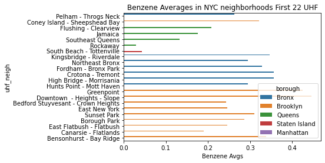

```python
barPlotFirst22(UNF,'Benzene Avgs', 'uhf_neigh', 'Benzene', 'borough')
```

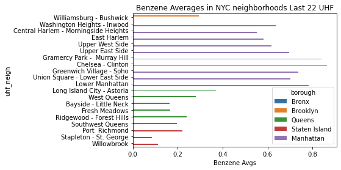

```python
barPlotLast22(UNF,'Benzene Avgs', 'uhf_neigh', 'Benzene', 'borough')
```

We see that benzene affects the neighborhoods of Manhattan the most, followed by Brooklyn. Benzene comes from gasoline fumes and crude oils. Benzene is released in the air by automobile exhaust and Manhattan happens to have the most traffic in New York City.

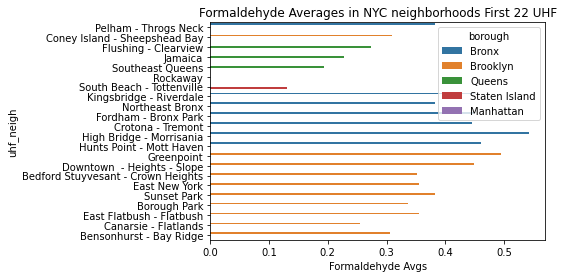

```python
barPlotFirst22(UNF,'Formaldehyde Avgs', 'uhf_neigh', 'Formaldehyde', 'borough')
```

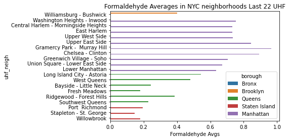

```python
barPlotLast22(UNF,'Formaldehyde Avgs', 'uhf_neigh', 'Formaldehyde', 'borough')
```

The Bronx and Manhattan have the most neighborhoods affected by formaldehyde. Formaldehyde is produced from during the combustion of fuels in vehicles and bulidings. It is also formed in the atmosphere with among other pollutants. Manhattan does have the most buildings and vehicles among the boroughs. The Bronx also consists of apartment bulidings.

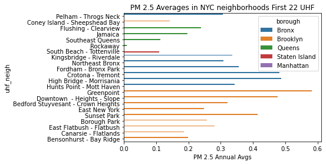

```python
barPlotFirst22(UNF,'PM 2.5 Annual Avgs', 'uhf_neigh', 'PM 2.5', 'borough')
```

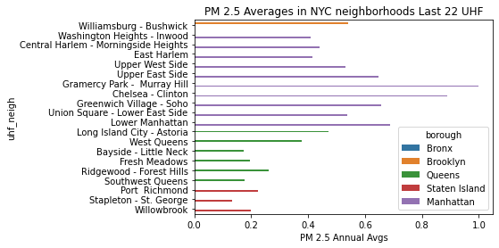

```python
barPlotLast22(UNF,'PM 2.5 Annual Avgs', 'uhf_neigh', 'PM 2.5', 'borough')
```

Fine Particulate Matter PM 2.5 primarly comes from automobile exhausts. Just like the benzene and formaldehyde pollutants, some of the neighborhoods of Manhattan, Bronx and Brooklyn mostly consist of PM 2.5 than other neighborhoods.

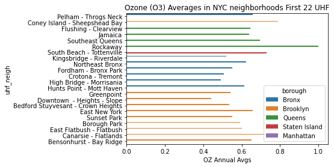

```python
barPlotFirst22(UNF,'OZ Annual Avgs', 'uhf_neigh', 'Ozone (O3)', 'borough')
```

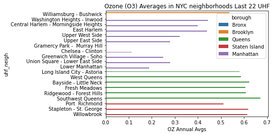

```python
barPlotLast22(UNF,'OZ Annual Avgs', 'uhf_neigh', 'Ozone (O3)', 'borough')
```

Ozone pollution is mostly present in Queens and Staten Island where it gets emitted from cars, power plants, and industrial boilers. There is a power plant in Astoria which contibute to the concentration in Queens. Also, it occurs when other organic compounds combine with the sunlight which comes from chemical emitted from cars.

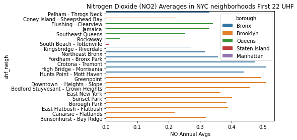

```python
barPlotFirst22(UNF,'NO Annual Avgs', 'uhf_neigh', 'Nitrogen Dioxide (NO2)', 'borough')
```

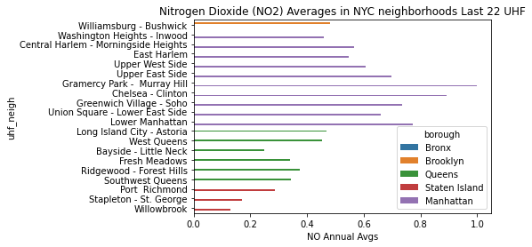

```python
barPlotLast22(UNF,'NO Annual Avgs', 'uhf_neigh', 'Nitrogen Dioxide (NO2)', 'borough')
```

Nitrogen dioxide is easily produced by combustion within stoves, water heaters, furnaces, and boilers. It is also produced from vehicles and power plants, as Brooklyn and the Bronx are more urban like therefore contributes to more homes producing nitrogen dioxide.

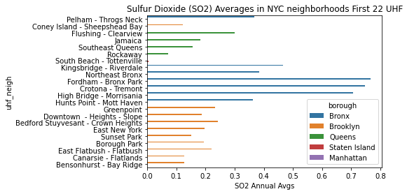

```python
barPlotFirst22(UNF,'SO2 Annual Avgs', 'uhf_neigh', 'Sulfur Dioxide (SO2)', 'borough')
```

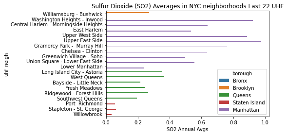

```python
barPlotLast22(UNF,'SO2 Annual Avgs', 'uhf_neigh', 'Sulfur Dioxide (SO2)', 'borough')
```

Sulfur dioxide comes from electric utilities, mostly the ones that burn coal. Also, boiler emissions produce sulfur dioxide, as well as other industrial facilities. Sulfur dioxide is mostly present within the neighborhoods of Manhattan and the Bronx.

## Boiler Emissions in New York City neighborhoods

```python
def LinePlotFirst22(df, col1, col2, name):
  x = df[col1][:22]
  y = df[col2][:22]
  plt.xlabel(col1)
  plt.ylabel(col2)
  plt.title(f"{name} Averages in NYC neighborhoods First 22 UHF")
  plt.xticks(rotation=90)
  plt.plot(x, y, color = 'black',
         linestyle = 'solid', marker = 'o',
         markerfacecolor = 'red', markersize = 12)
def LinePlotLast22(df, col1, col2, name):
  x = df[col1][22:]
  y = df[col2][22:]
  plt.xlabel(col1)
  plt.ylabel(col2)
  plt.title(f"{name} Averages in NYC neighborhoods Last 22 UHF")
  plt.xticks(rotation=90)
  plt.plot(x, y, color = 'black',
         linestyle = 'solid', marker = 'o',
         markerfacecolor = 'red', markersize = 12)
```

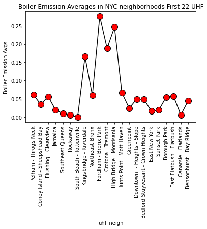

```python
LinePlotFirst22(UNF,'uhf_neigh', 'Boiler Emission Avgs', 'Boiler Emission')
```

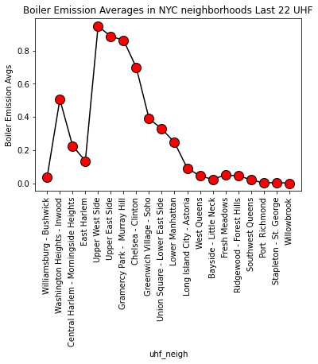

```python
LinePlotLast22(UNF,'uhf_neigh', 'Boiler Emission Avgs', 'Boiler Emission')
```

Boiler emissions are common in homes and bulidings that use gas. From the visualizations, we have that some neighborhoods in Manhattan and the Bronx consists of more pollutants emitted from boiler emissions. This could be because Manhattan and the Bronx consist of more bulidings which have more boilers.

```python
def ScatterPlot(df, col1, col2):
  sns.scatterplot(x = df[col1], y = df[col2]);
```

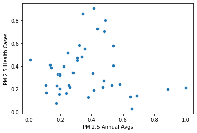

```python
ScatterPlot(UNF, 'PM 2.5 Annual Avgs', 'PM 2.5 Health Cases')
```

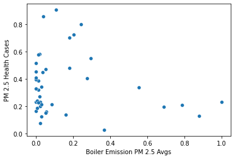

```python
ScatterPlot(UNF, 'Boiler Emission PM 2.5 Avgs', 'PM 2.5 Health Cases')
```

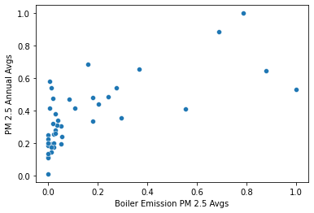

```python
ScatterPlot(UNF, 'Boiler Emission PM 2.5 Avgs', 'PM 2.5 Annual Avgs')
```

This shows correlation as the boiler emissions are one of the main causes of PM 2.5 concentrations. The correlation could be most likely in Manhattan and the Bronx.

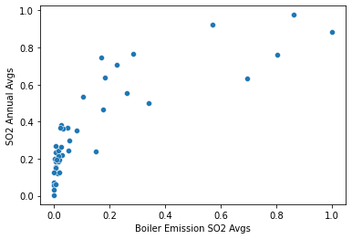

```python
ScatterPlot(UNF, 'Boiler Emission SO2 Avgs', 'SO2 Annual Avgs')
```

You can see that the boiler emissions and sulfur dioxide are heavily correlated as both increase. So it can be seen as one of the main causes of sulfur dioxide being in the air of New York City.

Here, the geojson file of the UHF42 of New York City is imported. It was obtained from the same link as the UHF42 dataset.

```python
uploaded = files.upload()
geo_data = gpd.read_file('uhf_42_dohmh_2009.geojson').dropna()
```

Upload widget is only available when the cell has been executed in the current browser session. Please rerun this cell to enable.

```
Saving uhf_42_dohmh_2009.geojson to uhf_42_dohmh_2009.geojson
```

Here is the map of the concentrations of the air pollutants all across New York City.

```python
map = folium.Map([40.7678,-73.9645], zoom_start = 10, tiles = "cartodbpositron")

tiles = ['stamenwatercolor', 'cartodbpositron', 'openstreetmap', 'stamenterrain']
for tile in tiles:
    folium.TileLayer(tile).add_to(map)

legendTitle = "Pollution in NYC"

map.add_child(folium.Choropleth(
        geo_data = geo_data,
        name = 'Pollution in NYC',
        data = UNF,
        columns = ['uhf_neigh', 'ConcentrationAvg'],
        key_on = 'properties.uhf_neigh',
        fill_color = 'YlOrRd',
        threshold_scale = [0,0.2,0.4,0.6,0.8,1],
        fill_opacity = 0.9,
        line_opacity = 0.4,
        legend_name = legendTitle,
        highlight = True
    )
)
folium.LayerControl().add_to(map)

map
```

Make this Notebook Trusted to load map: File -> Trust Notebook

[interactive chart not shown]

Also, here we have a map of the health cases relating to the air pollutants across New York City.

```python
map = folium.Map([40.7678,-73.9645], zoom_start = 10, tiles = "cartodbpositron")

tiles = ['stamenwatercolor', 'cartodbpositron', 'openstreetmap', 'stamenterrain']
for tile in tiles:
    folium.TileLayer(tile).add_to(map)

LegendTitle = "Health Cases in NYC"

map.add_child(folium.Choropleth(
        geo_data = geo_data,
        name = 'Health Cases in NYC',
        data = UNF,
        columns = ['uhf_neigh', 'HealthCaseAvg'],
        key_on = 'properties.uhf_neigh',
        legend_name = LegendTitle,
        fill_color = 'BuPu',
        threshold_scale = [0,0.2,0.4,0.6,0.8,1],
        fill_opacity = 0.9,
        line_opacity = .4,
        highlight = True
    )
)
folium.LayerControl().add_to(map)
map
```

Make this Notebook Trusted to load map: File -> Trust Notebook

[interactive chart not shown]

Overall, we see that pollution mainly affects Manhattan but the health cases are spread mostly in the Bronx. It could be because people commute to work in Manhattan then back to the borough they originally live in. The solution would be to use less fossil fuels and maybe invest in solar panels and electric cars as vehicle exhaust affect a lot of New Yorkers based on the pollutants the gas releases.

```python
!jupyter nbconvert --to html AirQualityControlinNewYorkCity.ipynb
```